# Code for the probabilities of Clovis atlatl use

# Setup

This code reads the data, fits models, calculates predictions, summarizes results, and draws the necessary plots to reproduce the short manuscript **The probabilities of Clovis atlatl use** by *Erik R. Otárola-Castillo* and *Benjamin J. Schoville*. The frozen model and its results are included in the manuscript’s final replication, which can be constructed by knitting `manuscript/letter.rmd`, producing a “read-only” Rmarkdown file that reproduces the MS word file.

The code formatting follows the reproducible RMarkdown and Stan frameworks used in Otárola-Castillo and Torquato (2018) and Otárola-Castillo et al. (2020, 2022, 2023).

The archaeological approach utilized here builds on earlier Bayesian models that used stone point morphology to infer stone-weapon delivery-technology. These examples were outlined by Otárola-Castillo and Torquato (2018) and Otárola-Castillo et al. (2023). Additional routines for working with posterior draws from models fitted in Stan through the R brms package, from scratch - so to speak, appear in Perri et al. (2019). See the end of this document for reference manuscript and code links.

Like in the works referenced above, the code presented here is not optimized to run as efficient software but rather to present the numerical work in a progressive, logical, and transparent manner.

```r
########################
# clear memory except the parameters list-object declared in the yaml code
########################
rm(list = setdiff(ls(), "params"))

########################
# Install only missing packages.
########################
required <- c(
  "knitr",
  "rmarkdown",
  "posterior",
  "ggplot2",
  "patchwork",
  "ragg",
  "statmod",
  "kableExtra"
)

missing <- required[
  !vapply(required, requireNamespace, logical(1), quietly = TRUE)
]

if (length(missing) > 0) {
  install.packages(missing)
}

########################
# Three ways to run this code. The default is to "report." This mode only reads completed results.
# recalculate uses computed chronology data and refits morphology models only.
# refit refits everything.
# "params" object comes from the yaml header above
########################
mode <- params$mode                       # "report", "refit", or "recalculate"
results_source <- params$results_source   # "frozen", "refit", or "recalculate"
run_id <- params$run_id                   # Output/report folder name;
saved_result_dir <- params$saved_draw_dir # Recalculate reads draws here;
save_draws <- params$save_draws           # TRUE keeps draws for later recalculation
show_code <- params$show_code             # TRUE displays code

calculate <- mode %in% c("refit", "recalculate")

########################
# Load the libraries.
# R: R Core Team (2026); CmdStanR: Gabry et al. (2025).
########################
library(knitr); library(statmod)

########################
# from stan: we recommend running this in a fresh R session or restarting your current session
# install.packages("cmdstanr", repos = c('https://stan-dev.r-universe.dev', getOption("repos")))
# then install cmdstanr::install_cmdstan()
# then call library cmdstanr IFF parameter mode is to refit
########################
if (mode=="refit") library(cmdstanr)

########################
# For ease of replication, all paths in Rstudio are relative to the Rstudio project.
########################
knitr::opts_chunk$set(echo = show_code, message = FALSE, warning = TRUE)
options(stringsAsFactors = FALSE, digits = 17)
frozen_dir <- "../results/frozen/run1"
data_directory <- if (results_source == "frozen") frozen_dir else
  file.path("../results", results_source, run_id)

if (calculate) {
  output_dir <- file.path("../results", mode, run_id)
  dir.create(output_dir, recursive = TRUE, showWarnings = FALSE)
  data_directory <- output_dir
  scratch_dir <- tempfile("clovis_")
  dir.create(scratch_dir)
  sampler_root <- scratch_dir
  saved_draw_dir <- file.path(saved_result_dir, "morphology")
}
```

# Get the data

Calls the .csv files.

```r
# Read all parameter values from csv file. Change those values for further sensitivity.
settings <- read.csv("../data/settings.csv")
s <- setNames(settings$value, settings$setting)

########################
# when recalculation is specified, only read the observations
########################
if (calculate) {
  ########################
  # TCSA background: Hughes (1998); Shea (2006).
  # Stone reference data: Thomas (1978); Shott (1997); Clarkson (2016).
  # Clarkson log-quartile summaries prepared using Wan et al. (2014), eqs. 14 and 16.
  # Thrusting summary: Shea (2006), Table 1; experiment: Shea et al. (2001, 2002).
  # Ethiopian javelins: Sahle and Lombard (2024), SOM Data 2; Sahle et al. (2023).
  # Nonlithic arrows: Lombard et al. (2024), Online Resource 1.
  ########################
  groups <- read.csv("../data/groups.csv")

  ########################
  # Vail measurements come from Gramly (1982), Table 2.
  ########################
  vail <- read.csv("../data/vail.csv")

  ########################
  # The Clovis summary data is from Eren et al. (2022), Tables 1 and 2.
  ########################
  eren <- read.csv("../data/eren.csv")
  stages <- read.csv("../data/stages.csv")
  prior_table <- read.csv("../data/prior.csv")
  class_order <- prior_table$class
  stage_order <- unique(stages$stage)
}
```

# Prepare the chronology models

Atlatl and bow chronologies are fitted separately. Each assumed to have had a deposition rate through time whenever the technology is present. We integrate small intervals to obtain the total likelihood that will contribute to the probability later on. The R code below prepares the integration intervals and passes them to the stan code.

```r
if (mode=="refit"){
########################
# Read the dated objects, measurements, and calibration curve.
# Atlatl dates: Eren et al. (2026), S1; bow dates: Buchanan et al. (2026).
########################
specimens <- read.csv("../data/specimens.csv")

########################
# RC date uncertainty: Berger and Libby (1967), p. 480; Hare et al. (2012), Table 6.
########################
rcdate <- read.csv("../data/assays.csv")

########################
# IntCal20 calibration curve: Reimer et al. (2020), downloaded complete table for calibration inside stan code from https://intcal.org/curves.html. The advantage of doing this in stan is building the likelihood of the chronology while keeping together the lab errors, calibration-curve uncertainty, multiple assays per specimen, and preservation model. We do not run the chance of passing calibrated data whose assumptions do not align. Plus there is a speed advantage of writing the loops in stan's C++ vs. R code.
########################
curve <- read.csv("../data/intcal.csv", comment.char = "#", header = FALSE)
curve <- curve[order(curve[[1]]), ]

########################
# Construct nodes to integrate calendar-age intervals using Gauss-Legendre quadrature (Golub and Welsch, 1969). statmod::gauss.quad() handles this. R prepares the quadrature grid, feeds it into stan to perform the radiocarbon likelihood integration, then estimates the posterior distribution of the deposition rate and the preservation weighted chronology. The deposition rate across calendar time within each technology's fit. Each rate (lambda) is estimated using a Poisson-process likelihood in chronology_model.stan (Kingman, 1993).
########################
cal_edges <- function(lo, hi) {
  sort(unique(c(lo, hi, seq(lo, hi, by = s["calendar_cell"]),
                curve[[1]][curve[[1]] > lo & curve[[1]] < hi])))
}

########################
# Compile a single list of necessary inputs per throwing technology.
########################
chronology_data <- function(technology) {
  ids <- specimens$record_id[specimens$technology_reported == technology]
  a <- rcdate[rcdate$record_id %in% ids, ]
  Q_mat <- as.integer(s[paste0("calendar_order_", technology)])
  rule <- statmod:::gauss.quad(Q_mat)
  edges <- cal_edges(0, as.vector(s["clovis_young"]))
  ec <- cal_edges(as.vector(s["clovis_young"]), as.vector(s["clovis_old"]))
  list(
    N = length(ids), M = nrow(a), specimen_id = match(a$record_id, ids),
    rc_age = a$age, rc_error = a$error, N_curve = nrow(curve),
    cal_age = curve[[1]], cal_mean = curve[[2]], cal_sd = curve[[3]],
    E = length(edges), edges = edges, E_clovis = length(ec), clovis_edges = ec,
    Q_mat = Q_mat, qx = rule$nodes, qw = rule$weight,
    h = as.vector(s["h"]),
    # Clovis interval, following the Eren et al paper 2026. "_young" is most recent "_old" is older
    clovis_young = as.vector(s["clovis_young"]), clovis_old = as.vector(s["clovis_old"]),
    rate_unit = as.vector(s["rate_unit"]), rate_shape = as.vector(s["rate_shape"]),
    rate_rate = as.vector(s["rate_rate"]),
    prior_absent = as.vector(s["prior_absent"]),
    # Wood-preservation curves freom Guyette et al. (2008); Perez et al. (2022).
    guyette_k = as.vector(s["guyette_k"]), perez_k = as.vector(s["perez_k"]),
    # archaeological site preservation function from Surovell et al. (2009).
    site_offset = as.vector(s["site_offset"]), site_exponent = as.vector(s["site_exponent"])
  )
}

chronology_starts <- c(80, 150, 100, 200)

chronology_init <- function(chain_id) {
  i <- (chain_id - 1L) %% length(chronology_starts) + 1L
  list(lambda = chronology_starts[i])
}

atlatl_data <- chronology_data("atlatl")
bow_data <- chronology_data("bow")

########################
# Compile the three stan models using cmdstanR, which uses all of stan's capabilities. Carpenter et al. (2017); Hoffman and Gelman (2014).
########################
chronology_model <- cmdstan_model("../models/chronology_model.stan")
clovis_model <- cmdstan_model("../models/clovis_target.stan")
reference_model <- cmdstan_model("../models/reference_morphology.stan")
}
```

# Summarize convergence

These are sampling diagnostics. We retain one for each fitted model.

```r
if (mode=="refit"){
  diagnostic_summary <- data.frame()

########################
# provide R-hat and effective sample sizes, Aki Vehtari et al. (2021).
########################
convergence <- function(fit, name, variables) {
  sm <- as.data.frame(posterior::summarise_draws(
    fit$draws(variables), "rhat", "ess_bulk", "ess_tail"))
  a <- fit$sampler_diagnostics(format = "draws_array")
  ebfmi <- numeric(dim(a)[2])
  for (chain in seq_len(dim(a)[2])) {
    energy <- a[, chain, "energy__"]
    ebfmi[chain] <- mean(diff(energy)^2) / var(energy)
  }
  data.frame(model = name, maximum_rhat = max(sm$rhat),
    minimum_bulk_ess = min(sm$ess_bulk), minimum_tail_ess = min(sm$ess_tail),
    divergences = sum(a[, , "divergent__"]),
    treedepth_hits = sum(a[, , "treedepth__"] >= s["max_treedepth"]),
    minimum_ebfmi = min(ebfmi))
}

}
```

# Fit the chronology

```r
if (mode=="refit") {
########################
# Fit atlatl chronology.
# parameter vals from read in .csv file, settings.
########################
dir.create(file.path(sampler_root, "atlatl"))
atlatl_fit <- chronology_model$sample(
  data = atlatl_data,
  chains = as.integer(s["chains"]),
  parallel_chains = as.integer(s["parallel_chains"]),
  threads_per_chain = as.integer(s["threads_per_chain"]),
  iter_warmup = as.integer(s["warmup"]),
  iter_sampling = as.integer(s["retained"]),
  adapt_delta = as.vector(s["adapt_delta"]),
  max_treedepth = as.integer(s["max_treedepth"]), init = chronology_init,
  seed = as.integer(s["seed_atlatl"]), output_dir = file.path(sampler_root, "atlatl"),
  output_basename = "atlatl", save_warmup = FALSE, sig_figs = as.integer(s["sig_figs"]),
  refresh = as.integer(s["refresh"])
)

########################
# Save one numbered CSV per atlatl chain.
########################
if (save_draws) {
  dir.create(file.path(output_dir, "atlatl"), showWarnings = FALSE)
  atlatl_fit$save_output_files(
    dir = file.path(output_dir, "atlatl"), basename = "atlatl",
    timestamp = FALSE, random = FALSE
  )
}
atlatl_fit$summary

write.table(as.data.frame(atlatl_fit$summary(c("lambda", "p_absent"))),
  file = "", quote = FALSE, row.names = FALSE, sep = "  ")
diagnostic_summary <- rbind(diagnostic_summary, convergence(atlatl_fit, "atlatl",
  c("lambda", "p_absent", "lp__")))

########################
# Fit bow chronology.
########################
dir.create(file.path(sampler_root, "bow"))
bow_fit <- chronology_model$sample(
  data = bow_data,
  chains = as.integer(s["chains"]),
  parallel_chains = as.integer(s["parallel_chains"]),
  threads_per_chain = as.integer(s["threads_per_chain"]),
  iter_warmup = as.integer(s["warmup"]),
  iter_sampling = as.integer(s["retained"]),
  adapt_delta = as.vector(s["adapt_delta"]),
  max_treedepth = as.integer(s["max_treedepth"]), init = chronology_init,
  seed = as.integer(s["seed_bow"]), output_dir = file.path(sampler_root, "bow"),
  output_basename = "bow", save_warmup = FALSE, sig_figs = as.integer(s["sig_figs"]),
  refresh = as.integer(s["refresh"])
)

########################
# Also save one numbered CSV per bow chain.
########################
if (save_draws) {
  dir.create(file.path(output_dir, "bow"), showWarnings = FALSE)
  bow_fit$save_output_files(
    dir = file.path(output_dir, "bow"), basename = "bow",
    timestamp = FALSE, random = FALSE
  )
}

########################
# report atlatl BF
write.table(as.data.frame(bow_fit$summary(c("lambda", "p_absent"))),
  file = "", quote = FALSE, row.names = FALSE, sep = "  ")
diagnostic_summary <- rbind(diagnostic_summary, convergence(bow_fit, "bow",
  c("lambda", "p_absent", "lp__")))
########################
}
```

# Calculate the Bayes factors

Average the conditional absence/presence probabilities first, and calculate monte carlo standard error. Convert that conditional average into posterior odds, then divide by prior odds.

```r
if(calculate){
########################
# Bayes factor = Posterior odds divided by prior odds of two hypotheses (models).
# Kass and Raftery (1995), provide framework for interpreting the support of bayes factor values.
# See application in Knell et al 2026 (https://www.researchgate.net/publication/416895962_The_Spatiotemporal_Distribution_of_Terminal_PleistoceneEarly_Holocene_Stemmed_Points_across_Western_North_America#full-text).
########################
bayes_factors <- data.frame()
for (technology in c("atlatl", "bow")) {
  if (mode == "refit") {
    fit <- if (technology == "atlatl") atlatl_fit else bow_fit
    p_array <- fit$draws("p_absent", format = "draws_array")
    p_draws <- matrix(p_array[, , 1], nrow = dim(p_array)[1], ncol = dim(p_array)[2])
  } else {
    # Read the saved chain count and length.
    chain_files <- list.files(file.path(saved_result_dir, technology),
      pattern = paste0("^", technology, "-[0-9]+\\.csv$"), full.names = TRUE)
    saved_probabilities <- vector("list", length(chain_files))
    for (chain in seq_along(chain_files)) {
      file <- chain_files[chain]
      saved <- read.csv(file, comment.char = "#", check.names = FALSE)
      saved_probabilities[[chain]] <- saved$p_absent
      if (save_draws) {
        dir.create(file.path(output_dir, technology), showWarnings = FALSE)
        file.copy(file, file.path(output_dir, technology, basename(file)), overwrite = TRUE)
      }
    }
    p_draws <- do.call(cbind, saved_probabilities)
  }
  p <- mean(p_draws)
  p_mcse <- posterior::mcse_mean(p_draws)
  # convert probabilities to log odds w qlogis
  log_bf <- qlogis(p) - qlogis(as.vector(s["prior_absent"]))
  log_bf_mcse <- p_mcse / (p * (1 - p))
  bayes_factors <- rbind(bayes_factors, data.frame(
    technology = technology, posterior_absent = p, p_absent_mcse = p_mcse,
    log_bf = log_bf, bayes_factor = exp(log_bf), log_bf_mcse = log_bf_mcse,
    bf_mcse = exp(log_bf) * log_bf_mcse))
}

########################
# Combine the two technologies.
########################
log_bf <- setNames(bayes_factors$log_bf, bayes_factors$technology)
log_bf_mcse <- setNames(bayes_factors$log_bf_mcse, bayes_factors$technology)
chronology <- data.frame(atlatl_present = c(0, 0, 1, 1), bow_present = c(0, 1, 0, 1),
  log_relative_evidence = as.vector(c(0, -log_bf["bow"], -log_bf["atlatl"], -sum(log_bf))))
if (mode == "recalculate") diagnostic_summary <- read.csv(file.path(saved_result_dir, "diagnostics.csv"))
}
```

# Transition to morphology and fit the Clovis and reference log-TCSA models

```r
if(calculate){
  run_dir <- file.path(output_dir, "morphology")
if (save_draws) dir.create(run_dir)
if (mode == "refit") {
  target_dir <- file.path(scratch_dir, "morphology", "target")
  dir.create(target_dir, recursive = TRUE)

  ########################
  # read in data, control, parameter, and hyperparameter values
  ########################
  clovis_fit <- clovis_model$sample(
    data = list(
      N_vail = nrow(vail),
      vail_tcsa = vail$tcsa_mm2,
      N_plains = eren$n,
      plains_mean_tcsa = eren$mean_mm2,
      plains_sd_tcsa = eren$sd_mm2,
      mu0 = s["mu0"],
      mu0_sd = s["mu0_sd"],
      sigma_scale = s["sigma_scale"]
    ),
    chains = as.integer(s["chains"]),
    parallel_chains = as.integer(s["parallel_chains"]),
    threads_per_chain = as.integer(s["threads_per_chain"]),
    iter_warmup = as.integer(s["warmup"]),
    iter_sampling = as.integer(s["retained"]),
    adapt_delta = as.vector(s["adapt_delta"]),
    max_treedepth = as.integer(s["max_treedepth"]),
    seed = as.integer(s["seed_clovis"]),
    output_dir = target_dir, save_warmup = FALSE,
    sig_figs = as.integer(s["sig_figs"]), refresh = as.integer(s["refresh"])
  )
  diagnostic_summary <- rbind(diagnostic_summary,
    convergence(clovis_fit, "target", c("mu", "sigma", "lp__")))

  sum.tbl <- clovis_fit$summary(c("mu", "sigma"))

  write.table(as.data.frame(sum.tbl),
    file = "", quote = FALSE, row.names = FALSE, sep = "    ")

  d <- posterior::as_draws_df(
    clovis_fit$draws(c("mu", "sigma"))
  )

  target_draws <- data.frame(
    chain = d$.chain,
    iteration = d$.iteration,
    mean = d$mu,
    sd = d$sigma
  )
} else {
  target_draws <- read.csv(
    file.path(saved_draw_dir, "target_draws.csv")
  )
  target_draws <- target_draws[, c("chain", "iteration", "mean", "sd")]
}
}
```

# Predict Clovis point TCSA

Average predictive densities over the target posterior. Batch-estimates retain the accepted Monte Carlo error calculation.

```r
if(calculate){
target_draws <- target_draws[order(target_draws$chain, target_draws$iteration), ]

########################
# Batch-means Monte Carlo error following Flegal and Jones (2010).
########################
target_draws$batch <- NA_integer_

for (chain in unique(target_draws$chain)) {
  ix <- which(target_draws$chain == chain)

  target_draws$batch[ix] <-
    (chain - 1) * s["batches"] +
    pmin(
      s["batches"],
      ceiling(seq_along(ix) / (length(ix) / s["batches"]))
    )
}
y <- sort(unique(round(c(
  seq(-20, 30, by = 0.025),
  seq(0, 8, by = 0.005)
), 12)))

delta <- diff(y)

quadrature <- c(
  delta[1] / 2,
  (head(delta, -1) + tail(delta, -1)) / 2,
  tail(delta, 1) / 2
)

B <- max(target_draws$batch)
target_density <- numeric(length(y))
target_batches <- matrix(0, B, length(y))
batch_sizes <- as.numeric(table(target_draws$batch))

for (first in seq(1, length(y), by = 64)) {
  ix <- first:min(first + 63, length(y))
  values <- matrix(0, nrow(target_draws), length(ix))

  for (j in seq_along(ix)) {
    values[, j] <- dnorm(
      y[ix[j]],
      target_draws$mean,
      target_draws$sd
    )
  }

  target_density[ix] <- colMeans(values)

  target_batches[, ix] <-
    rowsum(
      values,
      target_draws$batch,
      reorder = FALSE
    ) / batch_sizes
}

if (save_draws)
  write.csv(target_draws, file.path(run_dir, "target_draws.csv"), row.names = FALSE)
}
```

# Fit the reference groups and predict their TCSA values

```r
if (calculate){
density_rows <- data.frame()
morphology_results <- setNames(vector("list", length(stage_order)), stage_order)
for (stage in stage_order) {
  take <- match(stages$group_id[stages$stage == stage], groups$group_id)
  g <- groups[take, ]
  classes <- class_order[class_order %in% g$class]
  datasets <- unique(g$dataset)
  class_id <- match(g$class, classes)
  dataset_id <- match(g$dataset, datasets)
  n_deliv <- length(classes)
  n_ref <- nrow(g)
  prior0 <- as.matrix(prior_table[match(classes, class_order), c("absent", "present")])
  prior0 <- prior0 / sum(prior0)
  reference_density <- matrix(0, length(y), n_deliv)
  reference_batches <- vector("list", n_deliv)
  names(reference_batches) <- classes
  if (mode == "refit") {
    stage_dir <- file.path(scratch_dir, "morphology", stage)
    dir.create(stage_dir, showWarnings = FALSE, recursive = TRUE)
    stan_data <- list(n_deliv = n_deliv, n_ref = n_ref, ID = length(datasets), class_id = class_id,
      dataset_id = dataset_id, n = as.integer(g$n), ybar = g$ybar, sse = g$sse,
      mu0 = as.vector(s["mu0"]),
      mu0_sd = as.vector(s["mu0_sd"]), tau_class_prior_scale = as.vector(s["tau_class_scale"]),
      sigma0_prior_scale = as.vector(s["sigma_scale"]),
      tau_dataset_prior_scale = as.vector(s["tau_dataset_scale"]),
      tau_subgroup_prior_scale = as.vector(s["tau_group_scale"]))
    fit <- reference_model$sample(
      data = stan_data,
      seed = as.integer(s["seed"] + match(stage, stage_order)),
      chains = as.integer(s["chains"]),
      parallel_chains = as.integer(s["parallel_chains"]),
      threads_per_chain = as.integer(s["threads_per_chain"]),
      iter_warmup = as.integer(s["warmup"]),
      iter_sampling = as.integer(s["retained"]),
      adapt_delta = as.vector(s["adapt_delta"]),
      max_treedepth = as.integer(s["max_treedepth"]),
      save_warmup = FALSE, sig_figs = as.integer(s["sig_figs"]),
      output_dir = stage_dir, refresh = as.integer(s["reference_refresh"])
    )
    diagnostic_summary <- rbind(diagnostic_summary, convergence(fit, stage,
      c("sigma0", "tau_dataset", "tau_subgroup", "tau_class", "mu_class", "lp__")))
    write.table(as.data.frame(fit$summary(c(
      "sigma0", "tau_dataset", "tau_subgroup", "tau_class", "mu_class"))),
      file = "", quote = FALSE, row.names = FALSE, sep = "  ")
    draws <- as.data.frame(posterior::as_draws_df(fit$draws()))
    draws <- draws[order(draws$.chain, draws$.iteration), ]
    if (save_draws) {
      dir.create(file.path(run_dir, stage), recursive = TRUE, showWarnings = FALSE)
      write.csv(draws, file.path(run_dir, stage, "draws.csv"), row.names = FALSE)
    }
  } else {
    draws <- read.csv(file.path(saved_draw_dir, stage, "draws.csv"),
                      check.names = FALSE)
    draws <- draws[order(draws$.chain, draws$.iteration), ]
    if (save_draws) {
      dir.create(file.path(run_dir, stage), recursive = TRUE, showWarnings = FALSE)
      file.copy(file.path(saved_draw_dir, stage, "draws.csv"),
                file.path(run_dir, stage, "draws.csv"), overwrite = TRUE)
    }
  }
  N <- nrow(draws)

  ########################
  # Batch-means Monte Carlo error: Flegal and Jones (2010).
  ########################
  batch <- integer(N)
  for (chain in unique(draws$.chain)) {
    ix <- which(draws$.chain == chain)
    batch[ix] <- (chain - 1) * s["batches"] +
      pmin(s["batches"], ceiling(seq_along(ix) / (length(ix) / s["batches"])))
  }
  same_dataset <- outer(class_id, class_id, "==") & outer(dataset_id, dataset_id, "==")
  means <- variances <- matrix(0, N, n_ref)
  residual_sd <- as.matrix(draws[, paste0("sigma_group[", seq_len(n_ref), "]"), drop = FALSE])
  dataset_sd <- as.matrix(draws[, paste0("tau_dataset[", seq_len(n_deliv), "]"), drop = FALSE])
  group_sd <- as.matrix(draws[, paste0("tau_subgroup[", seq_len(n_deliv), "]"), drop = FALSE])
  for (i in seq_len(N)) {
    class_covariance <- matrix(s["mu0_sd"]^2, n_deliv, n_deliv) + diag(draws[["tau_class[1]"]][i]^2, n_deliv)
    covariance <- class_covariance[class_id, class_id, drop = FALSE] +
      same_dataset * dataset_sd[i, class_id]^2
    diag(covariance) <- diag(covariance) + group_sd[i, class_id]^2
    observation_covariance <- covariance
    diag(observation_covariance) <- diag(observation_covariance) + residual_sd[i, ]^2 / g$n
    triangular <- chol(observation_covariance)
    inverse <- chol2inv(triangular)
    alpha <- drop(inverse %*% (g$ybar - s["mu0"]))
    means[i, ] <- s["mu0"] + drop(covariance %*% alpha)
    variances[i, ] <- diag(covariance) - rowSums((covariance %*% inverse) * covariance)
  }
  variances <- pmax(variances, 0)

  batch_sizes <- as.numeric(table(batch))
  for (k in seq_along(classes)) {
    ix <- which(class_id == k)
    group_weight <- g$n[ix] / sum(g$n[ix])
    reference_batches[[k]] <- matrix(0, max(batch), length(y))
    for (first in seq(1, length(y), by = 64)) {
      grid <- first:min(first + 63, length(y))
      values <- matrix(0, N, length(grid))
      for (j in seq_along(ix)) {
        h <- ix[j]
        sd <- sqrt(variances[, h] + residual_sd[, h]^2)
        for (v in seq_along(grid)) {
          values[, v] <- values[, v] + group_weight[j] * dnorm(y[grid[v]], means[, h], sd)
        }
      }
      reference_density[grid, k] <- colMeans(values)
      reference_batches[[k]][, grid] <- rowsum(values, batch, reorder = FALSE) / batch_sizes
    }

  }
  for (k in seq_along(classes)) {
    density_rows <- rbind(density_rows, data.frame(stage = stage, class = classes[k],
      log_tcsa = y, density_log = reference_density[, k]))
  }
  density_rows <- rbind(density_rows, data.frame(stage = stage, class = "Clovis",
    log_tcsa = y, density_log = target_density))
  morphology_results[[stage]] <- list(
    classes = classes,
    prior = prior0,
    density = reference_density,
    batches = reference_batches,
    groups = g
  )
}
}
```

# Combine chronology and morphology

This weights the mean predictive densities by the earlier computed chronological evidence and the priors. Normalize at each tcsa, then average over the Clovis tcsa distribution, keep the Monte Carlo errors.

```r
if(calculate){
  q <- as.vector(s["q"])
log_evidence <- matrix(chronology$log_relative_evidence, nrow = 2L, byrow = TRUE)
evidence <- exp(log_evidence - max(log_evidence))
probabilities <- data.frame()
for (stage in stage_order) {
  morphology <- morphology_results[[stage]]
  classes <- morphology$classes
  class_prior <- morphology$prior
  reference_density <- morphology$density
  reference_batches <- morphology$batches
  n_deliv <- length(classes)
  joint_prior <- array(0, c(n_deliv, 2L, 2L), dimnames = list(
                         class = classes, atlatl_present = 0:1, bow_present = 0:1))
  for (j in seq_along(classes)) {
    bow_availability <- if (classes[j] == "bow") 1 else q
    for (a in 1:2) {
      joint_prior[j, a, 1] <- class_prior[j, a] * (1 - bow_availability)
      joint_prior[j, a, 2] <- class_prior[j, a] * bow_availability
    }
  }
  class_weights <- apply(sweep(joint_prior, c(2, 3), evidence, "*"), 1, sum)
  weighted_density <- sweep(reference_density, 2, class_weights, "*")
  denominator <- rowSums(weighted_density)
  point_probability <- weighted_density / denominator
  grid_weight <- quadrature * target_density
  result <- colSums(sweep(point_probability, 1, grid_weight, "*"))
  target_values <- target_batches %*% sweep(point_probability, 1, quadrature, "*")
  target_mcse <- apply(target_values, 2, sd) / sqrt(nrow(target_values))
  batch_count <- nrow(reference_batches[[classes[1]]])
  influence <- matrix(0, batch_count, n_deliv)
  for (j in seq_len(n_deliv)) {
    variation <- sweep(reference_batches[[classes[j]]], 2, reference_density[, j], "-")
    for (k in seq_len(n_deliv)) {
      derivative <- (grid_weight / denominator) * (as.numeric(j == k) * class_weights[k] -
                         point_probability[, k] * class_weights[j])
      influence[, k] <- influence[, k] + drop(variation %*% derivative)
    }
  }
  reference_mcse <- apply(influence, 2, sd) / sqrt(batch_count)
  morphology_mcse <- sqrt(target_mcse^2 + reference_mcse^2)

  weight_gradient <- matrix(0, n_deliv, 2)
  for (j in seq_len(n_deliv)) {
    for (a in 1:2) {
      for (b in 1:2) {
        contribution <- joint_prior[j, a, b] * evidence[a, b]
        weight_gradient[j, 1] <- weight_gradient[j, 1] - (a - 1) * contribution
        weight_gradient[j, 2] <- weight_gradient[j, 2] - (b - 1) * contribution
      }
    }
  }
  chronology_gradient <- matrix(0, n_deliv, 2)
  for (t in 1:2) {
    derivative_density <- sweep(reference_density, 2, weight_gradient[, t], "*")
    derivative_probability <- derivative_density / denominator -
       point_probability * (rowSums(derivative_density) / denominator)
    chronology_gradient[, t] <- colSums(derivative_probability * grid_weight)
  }
  chronology_mcse <- sqrt(rowSums(sweep(chronology_gradient, 2,
                              log_bf_mcse[c("atlatl", "bow")], "*")^2))
  total_mcse <- sqrt(morphology_mcse^2 + chronology_mcse^2)

  probabilities <- rbind(probabilities, data.frame(stage = stage, class = classes,
    probability = as.vector(result), target_mcse = as.vector(target_mcse),
    reference_mcse = as.vector(reference_mcse), morphology_mcse = as.vector(morphology_mcse),
    chronology_mcse = as.vector(chronology_mcse), total_mcse = as.vector(total_mcse),
    structure = "fixed", q = q))
}

}
```

# Save the recalculated results

```r
if(calculate){

########################
# Save final data for the tables.
########################
write.csv(bayes_factors, file.path(output_dir, "bayes_factors.csv"), row.names = FALSE)
write.csv(density_rows, file.path(output_dir, "density.csv"), row.names = FALSE)
write.csv(probabilities, file.path(output_dir, "probabilities.csv"), row.names = FALSE)
write.csv(diagnostic_summary, file.path(output_dir, "diagnostics.csv"), row.names = FALSE)
}
```

# Read the selected results

```r
########################
# "Report mode" begins here. It reads final results without recalculating or refitting.
########################
HomeFolder <- ".."
source("../scripts/helper_functions.R", local = TRUE)
diagnostics <- read.csv(file.path(data_directory, "diagnostics.csv"))
cat("Results:", data_directory)
```

```
## Results: ../results/frozen/run1
```

```r
########################
# These values are for display only. sprintf() rounds them precisely to "%.3f" (3 decimals) or "%.2e" (2 decimal scientific notation). The resulting CSVs retain values with their full precision.
########################
chronology_table <- data.frame(
  Technology = tools::toTitleCase(bayes_factors$technology),
  Absence = sprintf("%.3f", bayes_factors$posterior_absent),
  Presence = sprintf("%.3f", 1 - bayes_factors$posterior_absent),
  BF_absence_presence = sprintf("%.3f", bayes_factors$bayes_factor),
  MCSE_log_BF = sprintf("%.2e", bayes_factors$log_bf_mcse),
  MCSE_BF = sprintf("%.2e", bayes_factors$bf_mcse))

knitr::kable(chronology_table[1,], format = "pipe", row.names = FALSE,
  col.names = c("Technology", "P(absence)", "P(presence)",
    "BF (absence:presence)", "MCSE (log BF)", "MCSE (BF)"),
  align = c("l", rep("r", 5)),
  caption = "Clovis chronology: posterior probabilities and Bayes factors.")
```

Clovis chronology: posterior probabilities and Bayes factors.

| Technology | P(absence) | P(presence) | BF (absence:presence) | MCSE (log BF) | MCSE (BF) |
| --- | --- | --- | --- | --- | --- |
| Atlatl | 0.523 | 0.477 | 1.096 | 1.02e-04 | 1.12e-04 |

# Table 1

```r
knitr::kable(table1$display, format = "pipe", row.names = FALSE,
  col.names = c("Comparison", "Bow", "Atlatl", "Contact/thrusting",
    "Short-range throwing/thrusting", "Hand-thrown"),
  align = c("l", rep("r", 5)),
  caption = "Clovis weapon-delivery probabilities.")
```

Clovis weapon-delivery probabilities.

| Comparison | Bow | Atlatl | Contact/thrusting | Short-range throwing/thrusting | Hand-thrown |
| --- | --- | --- | --- | --- | --- |
| Stone tips | 0.049 | 0.951 | — | — | — |
| Add thrusting | 0.027 | 0.343 | 0.630 | — | — |
| Full comparison | 0.013 | 0.159 | 0.274 | 0.334 | 0.220 |

# Compare a new calculation with the frozen results

```r
if(calculate){

########################
# Display differences between new runs and the frozen runs without overiding files.
########################
frozen_bf <- read.csv(file.path(frozen_dir, "bayes_factors.csv"))
frozen_probabilities <- read.csv(file.path(frozen_dir, "probabilities.csv"))
i <- match(bayes_factors$technology, frozen_bf$technology)
bf_comparison <- data.frame(Technology = bayes_factors$technology,
  Frozen = sprintf("%.3f", frozen_bf$bayes_factor[i]),
  Recalculated = sprintf("%.3f", bayes_factors$bayes_factor),
  Difference = sprintf("%.2e", bayes_factors$bayes_factor - frozen_bf$bayes_factor[i]))
cat("\n\n", paste(as.character(knitr::kable(bf_comparison,
  format = "pipe", row.names = FALSE,
  col.names = c("Technology", "Previous baseline", "New fit", "Difference"),
  align = c("l", "r", "r", "r"),
  caption = "Chronology Bayes factors: prior baseline versus new fit.")), collapse = "\n"), "\n\n", sep = "")
i <- match(paste(probabilities$stage, probabilities$class),
           paste(frozen_probabilities$stage, frozen_probabilities$class))
probability_comparison <- data.frame(Stage = probabilities$stage, Class = probabilities$class,
  Frozen = sprintf("%.3f", frozen_probabilities$probability[i]),
  Recalculated = sprintf("%.3f", probabilities$probability),
  Difference = sprintf("%.2e", probabilities$probability - frozen_probabilities$probability[i]),
  MCSE = sprintf("%.2e", probabilities$total_mcse))
comparison_display <- probability_comparison
comparison_stages <- c(stone = "Stone tips", add_thrusting = "Add thrusting",
  add_nonlithic = "Full comparison")
comparison_classes <- c(bow = "Bow", atlatl = "Atlatl",
  contact_thrusting = "Contact/thrusting",
  short_dual_use = "Short-range throwing/thrusting", hand_thrown = "Hand-thrown")
comparison_display$Stage <- as.vector(comparison_stages[comparison_display$Stage])
comparison_display$Class <- as.vector(comparison_classes[comparison_display$Class])
cat("\n\n", paste(as.character(knitr::kable(comparison_display,
  format = "pipe", row.names = FALSE,
  col.names = c("Comparison", "Weapon class", "Previous baseline",
    "New fit", "Difference", "MCSE"),
  align = c("l", "l", rep("r", 4)),
  caption = "Delivery probabilities: frozen baseline vs new fit.")), collapse = "\n"), "\n\n", sep = "")

}
```

# Sampling diagnostics

```r
########################
# Recalculate reports its source fits' diagnostics.
########################
diagnostic_labels <- c(atlatl = "Atlatl", bow = "Bow", target = "Clovis target",
  stone = "Stone reference", add_thrusting = "Stone + thrusting",
  add_nonlithic = "Full reference")
diagnostics_display <- data.frame(Model = as.vector(diagnostic_labels[diagnostics$model]),
  Rhat = sprintf("%.3f", diagnostics$maximum_rhat),
  Bulk_ESS = sprintf("%.0f", diagnostics$minimum_bulk_ess),
  Tail_ESS = sprintf("%.0f", diagnostics$minimum_tail_ess),
  Divergences = diagnostics$divergences,
  Treedepth_hits = diagnostics$treedepth_hits,
  E_BFMI = sprintf("%.3f", diagnostics$minimum_ebfmi))
knitr::kable(diagnostics_display, format = "pipe", row.names = FALSE,
  col.names = c("Model", "Max. R-hat", "Min. bulk ESS", "Min. tail ESS",
    "Divergences", "Treedepth hits", "Min. E-BFMI"),
  align = c("l", rep("r", 6)),
  caption = "Stan sampling diagnostics for all models.")
```

Stan sampling diagnostics for all models.

| Model | Max. R-hat | Min. bulk ESS | Min. tail ESS | Divergences | Treedepth hits | Min. E-BFMI |
| --- | --- | --- | --- | --- | --- | --- |
| Atlatl | 1.000 | 11874 | 11376 | 0 | 0 | 0.952 |
| Bow | 1.000 | 11766 | 10810 | 0 | 0 | 0.967 |
| Clovis target | 1.000 | 16806 | 20288 | 0 | 0 | 0.950 |
| Stone reference | 1.000 | 16085 | 14450 | 0 | 0 | 0.879 |
| Stone + thrusting | 1.000 | 15862 | 14398 | 0 | 0 | 0.890 |
| Full reference | 1.000 | 16091 | 14776 | 0 | 0 | 0.889 |

# Figure 1

This figure is drawn from the selected saved densities and the frozen calibrated-date display.

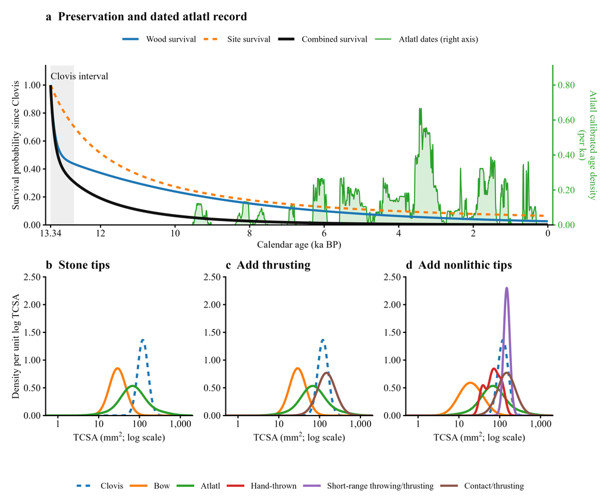

```r
knitr::include_graphics(figure_path)
```

# References cited

Berger, Rainer, and W. F. Libby. 1967. “UCLA Radiocarbon Dates VI.” *Radiocarbon* 9 (1): 477–504. https://doi.org/10.1017/S0033822200000692.

Buchanan, Briggs, Marcus J. Hamilton, Metin I. Eren, and Robert S. Walker. 2026. “Rapid adoption of bow technology across western North America ~1,400 years ago.” *PNAS Nexus* 5 (3): pgag040. https://doi.org/10.1093/pnasnexus/pgag040.

Carpenter, Bob, Andrew Gelman, Matthew D. Hoffman, et al. 2017. “Stan: A Probabilistic Programming Language.” *Journal of Statistical Software* 76 (1): 1–32. https://doi.org/10.18637/jss.v076.i01.

Clarkson, Chris. 2016. “Testing Archaeological Approaches to Determining Past Projectile Delivery Systems Using Ethnographic and Experimental Data.” In *Multidisciplinary Approaches to the Study of Stone Age Weaponry*, edited by Radu Iovita and Katsuhiro Sano. Springer. https://doi.org/10.1007/978-94-017-7602-8_13.

Eren, Metin I., Michelle R. Bebber, Edward J. Knell, Brett Story, and Briggs Buchanan. 2022. “Plains Paleoindian Projectile Point Penetration Potential.” *Journal of Anthropological Research* 78 (1): 84–112. https://doi.org/10.1086/717831.

Eren, Metin I., Michelle R. Bebber, Robert S. Walker, C. Reagan Johnson, and Briggs Buchanan. 2026. “Late Pleistocene Clovis atlatl hunting fails a chronological modeling test.” *Proceedings of the National Academy of Sciences* 123 (28): e2607964123. https://doi.org/10.1073/pnas.2607964123.

Flegal, James M., and Galin L. Jones. 2010. “Batch Means and Spectral Variance Estimators in Markov Chain Monte Carlo.” *The Annals of Statistics* 38 (2): 1034–70. https://doi.org/10.1214/09-AOS735.

Gabry, Jonah, Rok Češnovar, Andrew Johnson, and Steve Bronder. 2025. *cmdstanr: R Interface to CmdStan*. https://mc-stan.org/cmdstanr/.

Golub, Gene H., and John H. Welsch. 1969. “Calculation of Gauss Quadrature Rules.” *Mathematics of Computation* 23 (106): 221–30. https://doi.org/10.1090/S0025-5718-69-99647-1.

Gramly, R. M. 1982. *The Vail Site: A Palaeo-Indian Encampment in Maine*. Vol. 30. Bulletin of the Buffalo Society of Natural Sciences. Buffalo Society of Natural Sciences.

Guyette, R. P., D. C. Dey, and M. C. Stambaugh. 2008. “The Temporal Distribution and Carbon Storage of Large Oak Wood in Streams and Floodplain Deposits.” *Ecosystems* 11 (4): 643–53. https://doi.org/10.1007/s10021-008-9149-9.

Hare, P. Gregory, Christian D. Thomas, Timothy N. Topper, and Ruth M. Gotthardt. 2012. “The Archaeology of Yukon Ice Patches: New Artifacts, Observations, and Insights.” *Arctic* 65 (Supplement 1): 118–35. https://doi.org/10.14430/arctic4188.

Hoffman, Matthew D., and Andrew Gelman. 2014. “The No-U-Turn Sampler: Adaptively Setting Path Lengths in Hamiltonian Monte Carlo.” *Journal of Machine Learning Research* 15 (47): 1593–623. https://jmlr.org/papers/v15/hoffman14a.html.

Hughes, Susan S. 1998. “Getting to the Point: Evolutionary Change in Prehistoric Weaponry.” *Journal of Archaeological Method and Theory* 5 (4): 345–408. https://doi.org/10.1007/BF02428421.

Kass, Robert E., and Adrian E. Raftery. 1995. “Bayes Factors.” *Journal of the American Statistical Association* 90 (430): 773–95. https://doi.org/10.1080/01621459.1995.10476572.

Kingman, J. F. C. 1993. *Poisson Processes*. Vol. 3. Oxford Studies in Probability. Clarendon Press.

Knell, Edward J., Matthew E. Hill Jr., Richard L. Rosencrance, Erik Otárola-Castillo, Jackson C. Mueller, and Jon M. Erlandson. 2026. “The Spatiotemporal Distribution of Terminal Pleistocene/Early Holocene Stemmed Points across Western North America.” In *Paleoamerican Odyssey, 100 Years Beyond Folsom*, edited by Jessi J. Halligan, Lily E. Dempsey, Nicholas K. Bentley, Cody L. Preston, Kurt Rademaker, and Michael R. Waters. Texas A&M University Press. https://www.researchgate.net/publication/416895962_The_Spatiotemporal_Distribution_of_Terminal_PleistoceneEarly_Holocene_Stemmed_Points_across_Western_North_America#full-text.

Lombard, Marlize, M. G. Lotter, and M. V. Caruana. 2024. “The Tip Cross-Sectional Area (TCSA) Method Strengthened and Constrained with Ethno-Historical Material from Sub-Saharan Africa.” *Journal of Archaeological Method and Theory* 31 (1): 26–50. https://doi.org/10.1007/s10816-022-09595-1.

Otárola-Castillo, E. R., and M. G. Torquato. 2018. “Bayesian Statistics in Archaeology.” *Annual Review of Anthropology* 47 (1): 435–53. https://doi.org/10.1146/annurev-anthro-102317-045834.

Otárola-Castillo, E. R., M. G. Torquato, and C. E. Buck. 2023. “The Bayesian Inferential Paradigm in Archaeology.” In *Handbook of Archaeological Sciences*. https://doi.org/10.1002/9781119592112.ch59. https://github.com/dreoc/the-bayesian-inferential-paradigm-in-archaeology.

Otárola-Castillo, E. R., M. G. Torquato, and M. E. Hill. 2020. “Intensification Mechanisms Driving Dietary Change Among the Great Plains Big Game Hunters of North America.” In *Defining and Measuring Diversity in Archaeology*. https://github.com/dreoc/diet-diversity-mechanisms-paper.

Otárola-Castillo, E. R., M. G. Torquato, J. Wolfhagen, M. E. Hill Jr., and C. E. Buck. 2022. “Beyond Chronology, Using Bayesian Inference to Evaluate Hypotheses in Archaeology.” *Advances in Archaeological Practice* 10 (4): 397–413. https://github.com/dreoc/Bayesian-Archaeology-Beyond-Chronology.

Perez, S. B., J. M. Fraterrigo, and J. W. Dalling. 2022. “Interspecific wood trait variation predicts decreased carbon residence time in changing forests.” *Functional Ecology* 36: 674–85. https://doi.org/10.1111/1365-2435.13936.

Perri, A. R., J. M. Koster, E. R. Otárola-Castillo, J. L. Burns, and C. G. Cooper. 2019. “Dietary Variation Among Indigenous Nicaraguan Horticulturalists and Their Dogs: An Ethnoarchaeological Application of the Canine Surrogacy Approach.” *Journal of Anthropological Archaeology* 55: 101066. https://osf.io/dbxe9/overview.

R Core Team. 2026. *R: A Language and Environment for Statistical Computing*. 4.6.1. R Foundation for Statistical Computing. https://doi.org/10.32614/R.manuals. https://www.R-project.org/.

Reimer, Paula J., William E. N. Austin, Edouard Bard, et al. 2020. “The IntCal20 Northern Hemisphere Radiocarbon Age Calibration Curve (0–55 cal kBP).” *Radiocarbon* 62 (4): 725–57. https://doi.org/10.1017/RDC.2020.41.

Sahle, Yonatan, S. Ahmed, and S. J. Dira. 2023. “Javelin use among Ethiopia’s last indigenous hunters: Variability and further constraints on tip cross-sectional geometry.” *Journal of Anthropological Archaeology* 70: 101505. https://doi.org/10.1016/j.jaa.2023.101505.

Sahle, Yonatan, and Marlize Lombard. 2024. “The Evolution of Long-Range Hunting with Stone-Tipped Weapons during the Afrotropic Middle Stone Age: A Testable Framework Based on Tip Cross-Sectional Area.” *Quaternary* 7 (4): 50. https://doi.org/10.3390/quat7040050.

Shea, John J. 2006. “The origins of lithic projectile point technology: Evidence from Africa, the Levant, and Europe.” *Journal of Archaeological Science* 33 (6): 823–46. https://doi.org/10.1016/j.jas.2005.10.015.

Shea, John J., Kyle S. Brown, and Zachary J. Davis. 2002. “Controlled Experiments with Middle Paleolithic Spear Points: Levallois Points.” In *Experimental Archaeology: Replicating Past Objects, Behaviors, and Processes*, edited by James R. Mathieu. BAR International Series 1035. Archaeopress.

Shea, John, Zachary Davis, and Kyle Brown. 2001. “Experimental Tests of Middle Palaeolithic Spear Points Using a Calibrated Crossbow.” *Journal of Archaeological Science* 28 (8): 807–16. https://doi.org/10.1006/jasc.2000.0590.

Shott, Michael J. 1997. “Stones and Shafts Redux: The Metric Discrimination of Chipped-Stone Dart and Arrow Points.” *American Antiquity* 62 (1): 86–101. https://doi.org/10.2307/282380.

Surovell, Todd A., Judson B. Finley, Geoffrey M. Smith, P. Jeffrey Brantingham, and R. Kelly. 2009. “Correcting temporal frequency distributions for taphonomic bias.” *Journal of Archaeological Science* 36 (8): 1715–24. https://doi.org/10.1016/j.jas.2009.03.029.

Thomas, David Hurst. 1978. “Arrowheads and Atlatl Darts: How the Stones Got the Shaft.” *American Antiquity* 43 (3): 461–72. https://doi.org/10.2307/279405.

Vehtari, Aki, Andrew Gelman, Daniel Simpson, Bob Carpenter, and Paul-Christian Bürkner. 2021. “Rank-Normalization, Folding, and Localization: An Improved R-hat for Assessing Convergence of MCMC.” *Bayesian Analysis* 16 (2): 667–718. https://doi.org/10.1214/20-BA1221.

Wan, Xiang, Wenqian Wang, Jiming Liu, and Tiejun Tong. 2014. “Estimating the sample mean and standard deviation from the sample size, median, range and/or interquartile range.” *BMC Medical Research Methodology* 14: 135. https://doi.org/10.1186/1471-2288-14-135.